# SHRS Competitor Analysis - Tuition Comparison Report

SHRS MQE Capstone Team

2026-03-05

# 0 - About This Report

This report reads the CSVs produced by `competitor_02_tuition_pull.R` and presents Pitt’s tuition positioning against PA competitors for all 9 SHRS programs. No API calls are made here.

```r
library(tidyverse)
library(scales)
library(kableExtra)

DATA_DIR <- "competitor_data"

tier1_tuition      <- read_csv(file.path(DATA_DIR, "tier1_with_tuition.csv"), show_col_types = FALSE)
tier2_tuition      <- read_csv(file.path(DATA_DIR, "tier2_with_tuition.csv"), show_col_types = FALSE)
tuition_comparison <- read_csv(file.path(DATA_DIR, "tuition_comparison.csv"), show_col_types = FALSE)
tuition_latest     <- read_csv(file.path(DATA_DIR, "tuition_latest.csv"), show_col_types = FALSE)

PITT_UNITID <- 215293L

pitt_tuition <- tuition_latest |> filter(unitid == PITT_UNITID)
pitt_in  <- pitt_tuition$tuition_in_state[1]
pitt_out <- pitt_tuition$tuition_out_of_state[1]

cat("Pitt graduate tuition (in-state):", dollar(pitt_in), "\n")
```

```
## Pitt graduate tuition (in-state): $25,248
```

```r
cat("Pitt graduate tuition (out-of-state):", dollar(pitt_out), "\n")
```

```
## Pitt graduate tuition (out-of-state): $42,024
```

# 1 - Pitt vs. PA Competitors: Summary

How does Pitt’s graduate tuition compare to the average and median of competitors for each program?

```r
tuition_comparison |>
  arrange(desc(pitt_vs_avg_in)) |>
  mutate(
    pitt_in_state     = dollar(pitt_in_state),
    pitt_out_of_state = dollar(pitt_out_of_state),
    avg_in_state      = dollar(avg_in_state),
    med_in_state      = dollar(med_in_state),
    min_in_state      = dollar(min_in_state),
    max_in_state      = dollar(max_in_state),
    pitt_vs_avg_in    = dollar(pitt_vs_avg_in)
  ) |>
  select(
    Program            = shrs_program,
    `Pitt In-State`    = pitt_in_state,
    `Avg Competitor`   = avg_in_state,
    `Median Comp`      = med_in_state,
    `Min`              = min_in_state,
    `Max`              = max_in_state,
    `Pitt vs Avg`      = pitt_vs_avg_in
  ) |>
  kable() |>
  kable_styling(bootstrap_options = c("striped", "hover"), full_width = FALSE)
```

| Program | Pitt In-State | Avg Competitor | Median Comp | Min | Max | Pitt vs Avg |
| --- | --- | --- | --- | --- | --- | --- |
| HIM | $25,248 | $17,982 | $17,610 | $12,659 | $24,534 | $7,266 |
| SS | $25,248 | $19,575 | $15,402 | $2,318 | $60,189 | $5,673 |
| OTD | $25,248 | $21,325 | $19,428 | $11,630 | $37,390 | $3,923 |
| DPT | $25,248 | $23,224 | $21,120 | $11,630 | $51,610 | $2,024 |
| SLP | $25,248 | $23,422 | $17,964 | $1,455 | $60,189 | $1,826 |
| PAS | $25,248 | $24,399 | $21,820 | $11,438 | $53,293 | $849 |
| AuD | $25,248 | $24,591 | $15,448 | $11,438 | $60,189 | $657 |
| AT | NA | $20,036 | $16,742 | $7,020 | $53,293 | NA |
| DN | NA | $16,720 | $13,050 | $11,438 | $37,074 | NA |

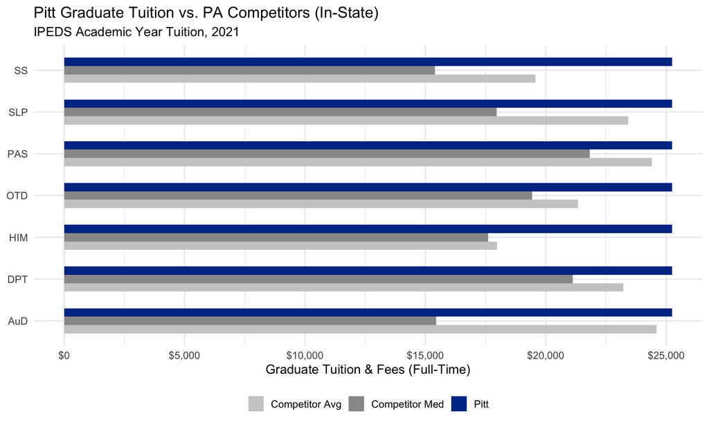

```r
tuition_comparison |>
  filter(!is.na(pitt_in_state)) |>
  select(shrs_program, Pitt = pitt_in_state, `Competitor Avg` = avg_in_state,
         `Competitor Med` = med_in_state) |>
  pivot_longer(-shrs_program, names_to = "measure", values_to = "tuition") |>
  ggplot(aes(x = reorder(shrs_program, tuition, max),
             y = tuition, fill = measure)) +
  geom_col(position = "dodge", width = 0.6) +
  coord_flip() +
  scale_y_continuous(labels = dollar) +
  scale_fill_manual(values = c(
    "Pitt" = "#003594",
    "Competitor Avg" = "#CCCCCC",
    "Competitor Med" = "#999999"
  )) +
  labs(
    title = "Pitt Graduate Tuition vs. PA Competitors (In-State)",
    subtitle = "IPEDS Academic Year Tuition, 2021",
    x = NULL, y = "Graduate Tuition & Fees (Full-Time)", fill = NULL
  ) +
  theme_minimal(base_size = 13) +
  theme(legend.position = "bottom")
```

# 2 - Tuition Range by Program

Where does Pitt fall within the full range of competitor tuition?

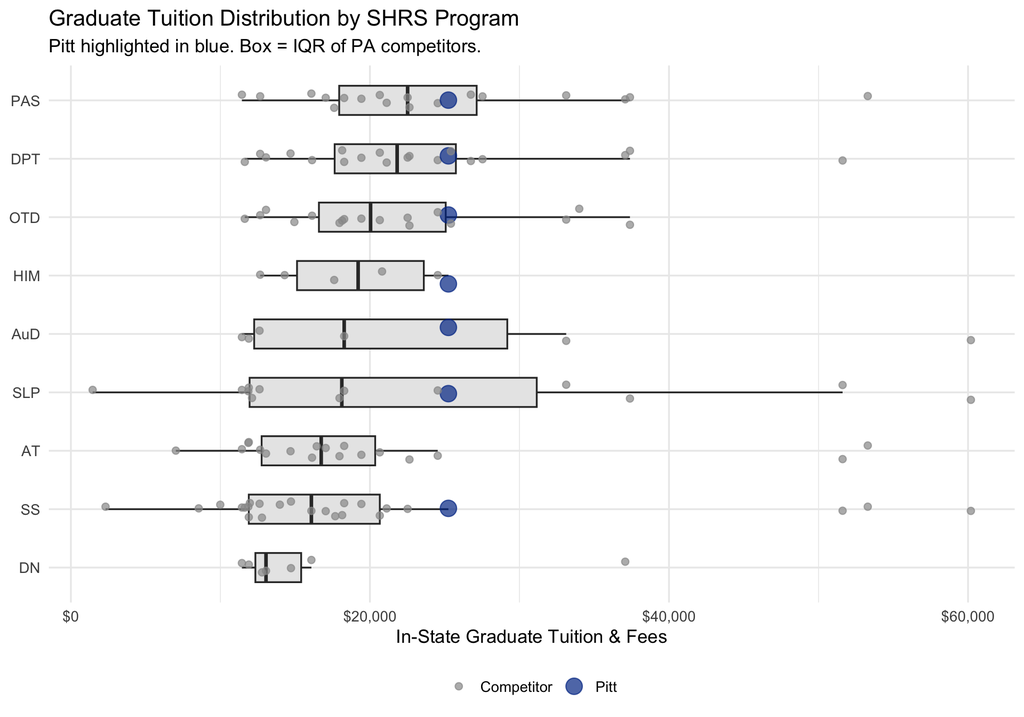

```r
tier1_tuition |>
  filter(!is.na(tuition_in_state)) |>
  ggplot(aes(x = reorder(shrs_program, tuition_in_state, median),
             y = tuition_in_state)) +
  geom_boxplot(fill = "#E8E8E8", outlier.shape = NA, width = 0.5) +
  geom_jitter(aes(color = is_pitt, size = is_pitt),
              width = 0.15, alpha = 0.7) +
  scale_y_continuous(labels = dollar) +
  scale_color_manual(values = c("FALSE" = "#999999", "TRUE" = "#003594"),
                     labels = c("Competitor", "Pitt")) +
  scale_size_manual(values = c("FALSE" = 2, "TRUE" = 5),
                    labels = c("Competitor", "Pitt")) +
  coord_flip() +
  labs(
    title = "Graduate Tuition Distribution by SHRS Program",
    subtitle = "Pitt highlighted in blue. Box = IQR of PA competitors.",
    x = NULL, y = "In-State Graduate Tuition & Fees",
    color = NULL, size = NULL
  ) +
  theme_minimal(base_size = 13) +
  theme(legend.position = "bottom")
```

# 3 - Detailed Tuition by Program

```r
for (prog in sort(unique(tier1_tuition$shrs_program))) {

  prog_data <- tier1_tuition |>
    filter(shrs_program == prog, !is.na(tuition_in_state)) |>
    arrange(tuition_in_state)

  if (nrow(prog_data) == 0) next

  cat(paste0("\n## ", prog, "\n\n"))

  # Table
  prog_data |>
    mutate(
      Institution = if_else(is_pitt, paste0("**", inst_name, " (PITT)**"), inst_name),
      tuition_in_state = dollar(tuition_in_state),
      tuition_out_of_state = dollar(tuition_out_of_state)
    ) |>
    select(
      Institution,
      City = city,
      `In-State` = tuition_in_state,
      `Out-of-State` = tuition_out_of_state,
      `Awards` = total_awards
    ) |>
    kable() |>
    kable_styling(bootstrap_options = c("striped", "hover"), full_width = FALSE) |>
    print()

  # Chart
  p <- prog_data |>
    ggplot(aes(x = reorder(inst_name, tuition_in_state),
               y = tuition_in_state, fill = is_pitt)) +
    geom_col(width = 0.6) +
    coord_flip() +
    scale_y_continuous(labels = dollar) +
    scale_fill_manual(values = c("FALSE" = "#CCCCCC", "TRUE" = "#003594"),
                      guide = "none") +
    labs(title = paste0(prog, ": In-State Graduate Tuition"),
         x = NULL, y = "Tuition & Fees") +
    theme_minimal(base_size = 11)
  print(p)

  cat("\n\n")
}
```

## AT

| Institution | City | In-State | Out-of-State | Awards |
| --- | --- | --- | --- | --- |
| Clarks Summit University | Clarks Summit | $7,020 | $7,020 | 8 |
| Marywood University | Scranton | $11,438 | $11,438 | 8 |
| East Stroudsburg University of Pennsylvania | East Stroudsburg | $11,868 | $16,728 | 260 |
| West Chester University of Pennsylvania | West Chester | $11,898 | $16,758 | 148 |
| Slippery Rock University of Pennsylvania | Slippery Rock | $12,659 | $18,216 | 44 |
| Messiah University | Mechanicsburg | $13,050 | $13,050 | 28 |
| Neumann University | Aston | $14,690 | $14,690 | 4 |
| Alvernia University | Reading | $16,130 | $16,130 | 28 |
| Waynesburg University | Waynesburg | $16,440 | $16,440 | 44 |
| Mercyhurst University | Erie | $17,043 | $17,043 | 36 |
| Moravian University | Bethlehem | $17,964 | $17,964 | 56 |
| Temple University | Philadelphia | $18,278 | $24,812 | 96 |
| Chatham University | Pittsburgh | $19,428 | $19,428 | 16 |
| Gannon University | Erie | $20,660 | $20,660 | 28 |
| Thomas Jefferson University | Philadelphia | $22,644 | $22,644 | 32 |
| Duquesne University | Pittsburgh | $24,534 | $24,534 | 28 |
| Lebanon Valley College | Annville | $51,610 | $51,610 | 32 |
| King’s College | Wilkes-Barre | $53,293 | $53,293 | 32 |

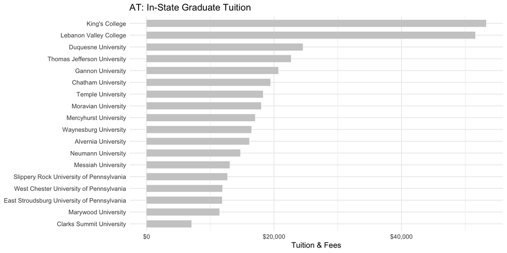

## AuD

| Institution | City | In-State | Out-of-State | Awards |
| --- | --- | --- | --- | --- |
| Marywood University | Scranton | $11,438 | $11,438 | 176 |
| West Chester University of Pennsylvania | West Chester | $11,898 | $16,758 | 452 |
| Indiana University of Pennsylvania-Main Campus | Indiana | $12,618 | $18,207 | 204 |
| Temple University | Philadelphia | $18,278 | $24,812 | 428 |
| **University of Pittsburgh-Pittsburgh Campus (PITT)** | Pittsburgh | $25,248 | $42,024 | 500 |
| Salus University | Elkins Park | $33,125 | $33,125 | 232 |
| Thiel College | Greenville | $60,189 | $60,189 | 52 |

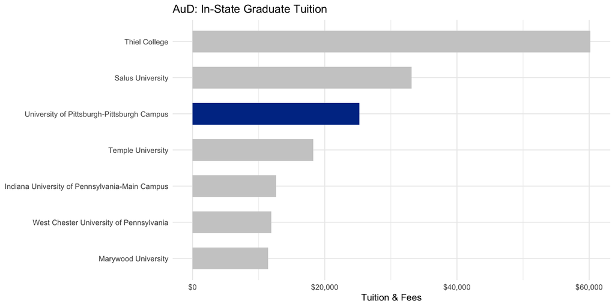

## DN

| Institution | City | In-State | Out-of-State | Awards |
| --- | --- | --- | --- | --- |
| Marywood University | Scranton | $11,438 | $11,438 | 48 |
| West Chester University of Pennsylvania | West Chester | $11,898 | $16,758 | 384 |
| Immaculata University | Immaculata | $12,780 | $12,780 | 16 |
| Messiah University | Mechanicsburg | $13,050 | $13,050 | 72 |
| Cedar Crest College | Allentown | $14,719 | $14,719 | 108 |
| Seton Hill University | Greensburg | $16,084 | $16,084 | 12 |
| Drexel University | Philadelphia | $37,074 | $37,074 | 52 |

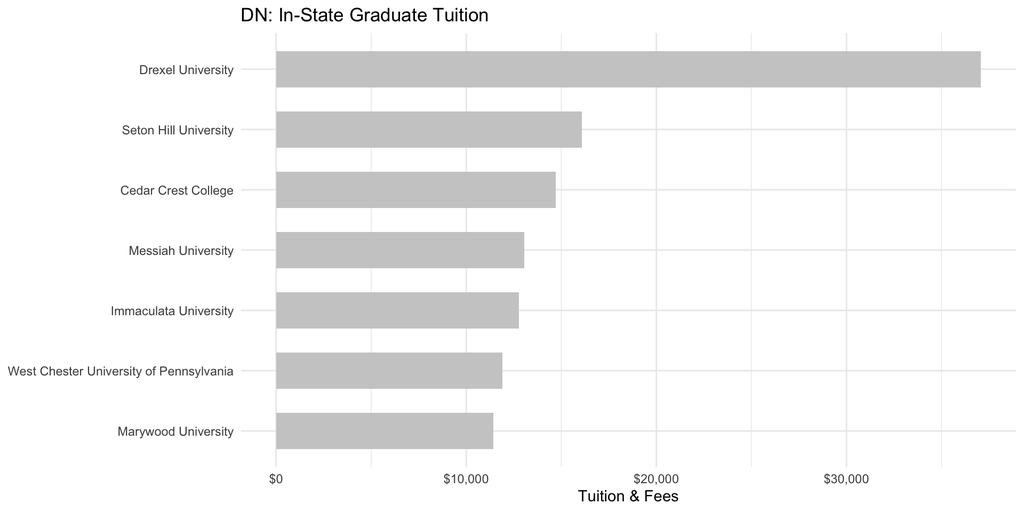

## DPT

| Institution | City | In-State | Out-of-State | Awards |
| --- | --- | --- | --- | --- |
| University of Scranton | Scranton | $11,630 | $11,630 | 280 |
| Slippery Rock University of Pennsylvania | Slippery Rock | $12,659 | $18,216 | 192 |
| Messiah University | Mechanicsburg | $13,050 | $13,050 | 144 |
| Neumann University | Aston | $14,690 | $14,690 | 124 |
| Alvernia University | Reading | $16,130 | $16,130 | 96 |
| Saint Joseph’s University | Philadelphia | $18,144 | $18,144 | 260 |
| Temple University | Philadelphia | $18,278 | $24,812 | 192 |
| Chatham University | Pittsburgh | $19,428 | $19,428 | 180 |
| Gannon University | Erie | $20,660 | $20,660 | 308 |
| DeSales University | Center Valley | $21,120 | $21,120 | 108 |
| Saint Francis University | Loretto | $22,520 | $22,520 | 156 |
| Thomas Jefferson University | Philadelphia | $22,644 | $22,644 | 244 |
| Duquesne University | Pittsburgh | $24,534 | $24,534 | 368 |
| **University of Pittsburgh-Pittsburgh Campus (PITT)** | Pittsburgh | $25,248 | $42,024 | 272 |
| Widener University | Chester | $25,416 | $25,416 | 172 |
| Philadelphia College of Osteopathic Medicine | Philadelphia | $26,748 | $26,748 | 160 |
| Arcadia University | Glenside | $27,530 | $27,530 | 1052 |
| Drexel University | Philadelphia | $37,074 | $37,074 | 248 |
| Misericordia University | Dallas | $37,390 | $37,390 | 188 |
| Lebanon Valley College | Annville | $51,610 | $51,610 | 188 |

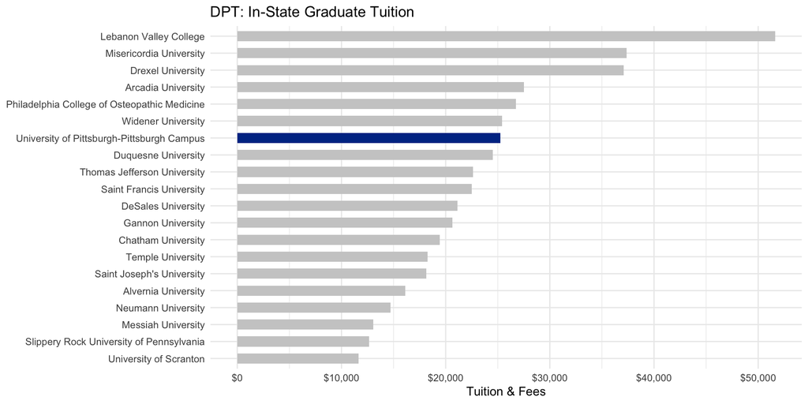

## HIM

| Institution | City | In-State | Out-of-State | Awards |
| --- | --- | --- | --- | --- |
| Slippery Rock University of Pennsylvania | Slippery Rock | $12,659 | $18,216 | 24 |
| Peirce College | Philadelphia | $14,296 | $14,296 | 12 |
| Pennsylvania College of Technology | Williamsport | $17,610 | $25,170 | 40 |
| Carlow University | Pittsburgh | $20,812 | $20,812 | 28 |
| Duquesne University | Pittsburgh | $24,534 | $24,534 | 20 |
| **University of Pittsburgh-Pittsburgh Campus (PITT)** | Pittsburgh | $25,248 | $42,024 | 8 |

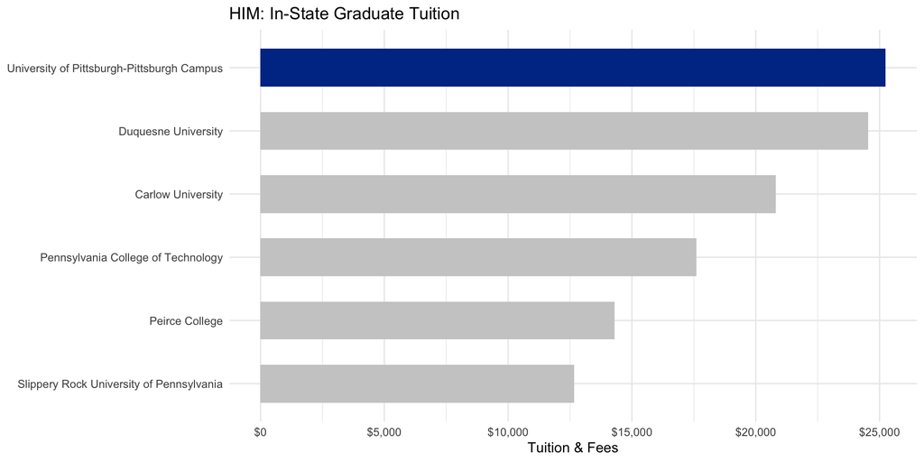

## OTD

| Institution | City | In-State | Out-of-State | Awards |
| --- | --- | --- | --- | --- |
| University of Scranton | Scranton | $11,630 | $11,630 | 224 |
| Slippery Rock University of Pennsylvania | Slippery Rock | $12,659 | $18,216 | 248 |
| Messiah University | Mechanicsburg | $13,050 | $13,050 | 112 |
| Gwynedd Mercy University | Gwynedd Valley | $14,947 | $14,947 | 116 |
| Alvernia University | Reading | $16,130 | $16,130 | 340 |
| Moravian University | Bethlehem | $17,964 | $17,964 | 128 |
| Saint Joseph’s University | Philadelphia | $18,144 | $18,144 | 324 |
| Temple University | Philadelphia | $18,278 | $24,812 | 152 |
| Chatham University | Pittsburgh | $19,428 | $19,428 | 232 |
| Gannon University | Erie | $20,660 | $20,660 | 392 |
| Saint Francis University | Loretto | $22,520 | $22,520 | 264 |
| Thomas Jefferson University | Philadelphia | $22,644 | $22,644 | 564 |
| Duquesne University | Pittsburgh | $24,534 | $24,534 | 232 |
| **University of Pittsburgh-Pittsburgh Campus (PITT)** | Pittsburgh | $25,248 | $42,024 | 256 |
| Widener University | Chester | $25,416 | $25,416 | 52 |
| Salus University | Elkins Park | $33,125 | $33,125 | 220 |
| Elizabethtown College | Elizabethtown | $34,000 | $34,000 | 236 |
| Misericordia University | Dallas | $37,390 | $37,390 | 280 |

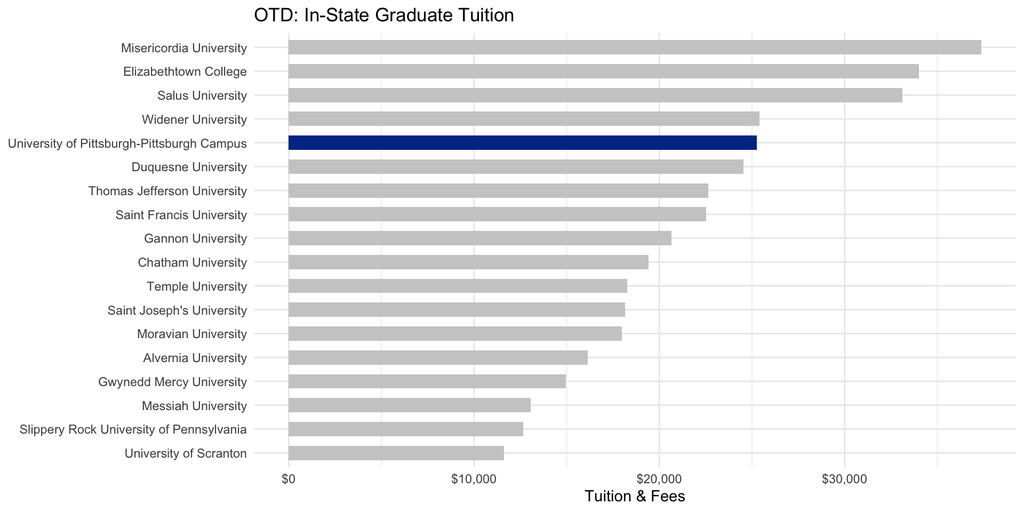

## PAS

| Institution | City | In-State | Out-of-State | Awards |
| --- | --- | --- | --- | --- |
| Marywood University | Scranton | $11,438 | $11,438 | 228 |
| Slippery Rock University of Pennsylvania | Slippery Rock | $12,659 | $18,216 | 128 |
| Seton Hill University | Greensburg | $16,084 | $16,084 | 144 |
| Mercyhurst University | Erie | $17,043 | $17,043 | 112 |
| Pennsylvania College of Technology | Williamsport | $17,610 | $25,170 | 76 |
| Temple University | Philadelphia | $18,278 | $24,812 | 124 |
| Chatham University | Pittsburgh | $19,428 | $19,428 | 260 |
| Gannon University | Erie | $20,660 | $20,660 | 336 |
| DeSales University | Center Valley | $21,120 | $21,120 | 300 |
| Saint Francis University | Loretto | $22,520 | $22,520 | 368 |
| Thomas Jefferson University | Philadelphia | $22,644 | $22,644 | 512 |
| Duquesne University | Pittsburgh | $24,534 | $24,534 | 400 |
| **University of Pittsburgh-Pittsburgh Campus (PITT)** | Pittsburgh | $25,248 | $42,024 | 240 |
| Philadelphia College of Osteopathic Medicine | Philadelphia | $26,748 | $26,748 | 352 |
| Arcadia University | Glenside | $27,530 | $27,530 | 388 |
| Salus University | Elkins Park | $33,125 | $33,125 | 196 |
| Drexel University | Philadelphia | $37,074 | $37,074 | 288 |
| Misericordia University | Dallas | $37,390 | $37,390 | 76 |
| King’s College | Wilkes-Barre | $53,293 | $53,293 | 272 |

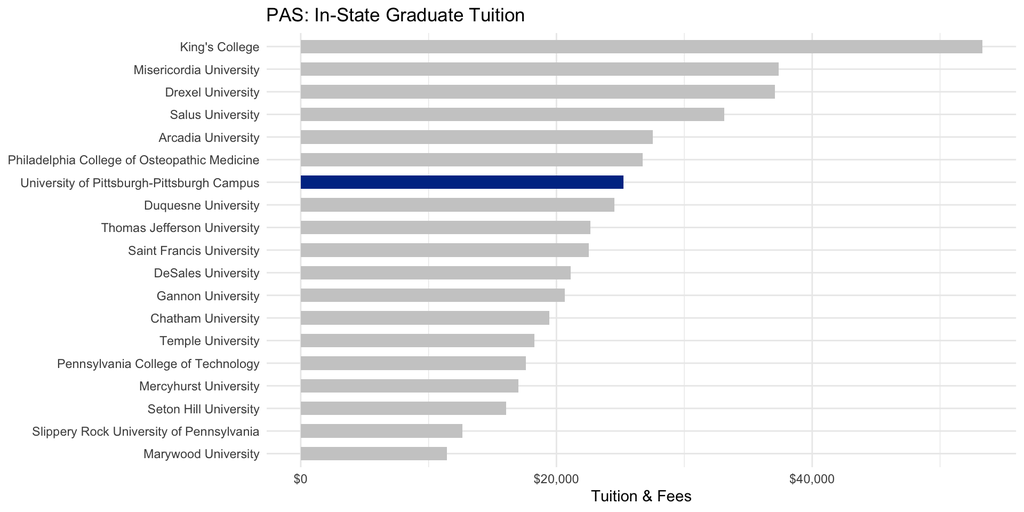

## SLP

| Institution | City | In-State | Out-of-State | Awards |
| --- | --- | --- | --- | --- |
| La Salle University | Philadelphia | $1,455 | $1,455 | 256 |
| Marywood University | Scranton | $11,438 | $11,438 | 176 |
| East Stroudsburg University of Pennsylvania | East Stroudsburg | $11,868 | $16,728 | 196 |
| West Chester University of Pennsylvania | West Chester | $11,898 | $16,758 | 452 |
| Geneva College | Beaver Falls | $12,114 | $12,114 | 28 |
| Indiana University of Pennsylvania-Main Campus | Indiana | $12,618 | $18,207 | 204 |
| Moravian University | Bethlehem | $17,964 | $17,964 | 100 |
| Temple University | Philadelphia | $18,278 | $24,812 | 428 |
| Duquesne University | Pittsburgh | $24,534 | $24,534 | 252 |
| **University of Pittsburgh-Pittsburgh Campus (PITT)** | Pittsburgh | $25,248 | $42,024 | 500 |
| Salus University | Elkins Park | $33,125 | $33,125 | 144 |
| Misericordia University | Dallas | $37,390 | $37,390 | 156 |
| Lebanon Valley College | Annville | $51,610 | $51,610 | 124 |
| Thiel College | Greenville | $60,189 | $60,189 | 52 |

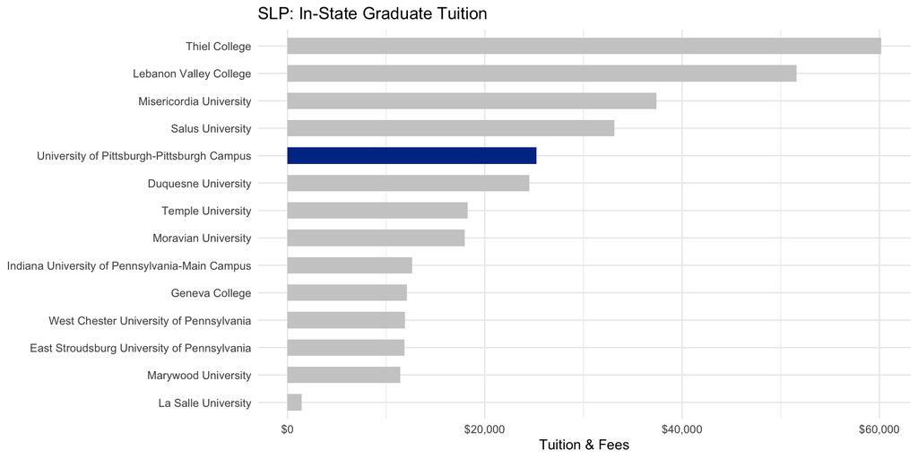

## SS

| Institution | City | In-State | Out-of-State | Awards |
| --- | --- | --- | --- | --- |
| Cabrini University | Radnor | $2,318 | $2,318 | 60 |
| Grove City College | Grove City | $8,550 | $8,550 | 84 |
| Wilson College | Chambersburg | $9,990 | $9,990 | 32 |
| Marywood University | Scranton | $11,438 | $11,438 | 16 |
| University of Scranton | Scranton | $11,630 | $11,630 | 204 |
| East Stroudsburg University of Pennsylvania | East Stroudsburg | $11,868 | $16,728 | 264 |
| West Chester University of Pennsylvania | West Chester | $11,898 | $16,758 | 36 |
| Shippensburg University of Pennsylvania | Shippensburg | $11,970 | $16,830 | 140 |
| La Roche University | Pittsburgh | $12,619 | $12,619 | 16 |
| Immaculata University | Immaculata | $12,780 | $12,780 | 56 |
| Eastern University | Saint Davids | $13,976 | $13,976 | 28 |
| Cedar Crest College | Allentown | $14,719 | $14,719 | 52 |
| Seton Hill University | Greensburg | $16,084 | $16,084 | 80 |
| Mercyhurst University | Erie | $17,043 | $17,043 | 36 |
| Chestnut Hill College | Philadelphia | $17,680 | $17,680 | 84 |
| Saint Joseph’s University | Philadelphia | $18,144 | $18,144 | 12 |
| Temple University | Philadelphia | $18,278 | $24,812 | 400 |
| Chatham University | Pittsburgh | $19,428 | $19,428 | 100 |
| Gannon University | Erie | $20,660 | $20,660 | 252 |
| DeSales University | Center Valley | $21,120 | $21,120 | 84 |
| Saint Francis University | Loretto | $22,520 | $22,520 | 44 |
| **University of Pittsburgh-Pittsburgh Campus (PITT)** | Pittsburgh | $25,248 | $42,024 | 164 |
| Lebanon Valley College | Annville | $51,610 | $51,610 | 324 |
| King’s College | Wilkes-Barre | $53,293 | $53,293 | 96 |
| Thiel College | Greenville | $60,189 | $60,189 | 28 |

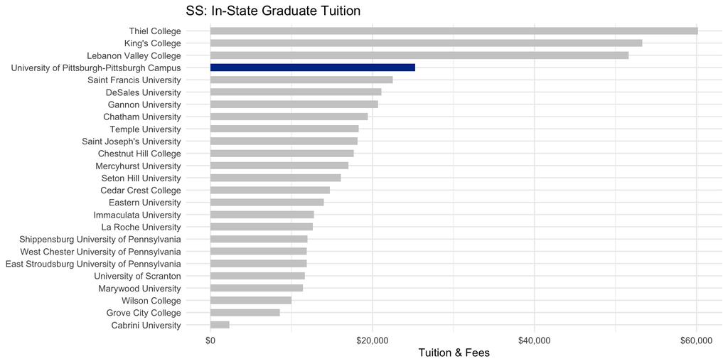

# 4 - Regional Tuition Comparison (Pittsburgh-Erie)

How does Pitt compare to just the local competitors?

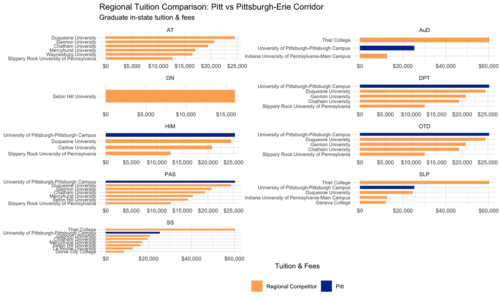

```r
tier2_tuition |>
  filter(!is.na(tuition_in_state)) |>
  ggplot(aes(x = reorder(inst_name, tuition_in_state),
             y = tuition_in_state, fill = is_pitt)) +
  geom_col(width = 0.6) +
  coord_flip() +
  facet_wrap(~ shrs_program, scales = "free", ncol = 2) +
  scale_y_continuous(labels = dollar) +
  scale_fill_manual(values = c("FALSE" = "#FDAE61", "TRUE" = "#003594"),
                    labels = c("Regional Competitor", "Pitt")) +
  labs(
    title = "Regional Tuition Comparison: Pitt vs Pittsburgh-Erie Corridor",
    subtitle = "Graduate in-state tuition & fees",
    x = NULL, y = "Tuition & Fees", fill = NULL
  ) +
  theme_minimal(base_size = 10) +
  theme(legend.position = "bottom",
        axis.text.y = element_text(size = 7))
```

# 5 - In-State vs Out-of-State Spread

How much more do out-of-state students pay? This matters for understanding cost competitiveness for students crossing state lines.

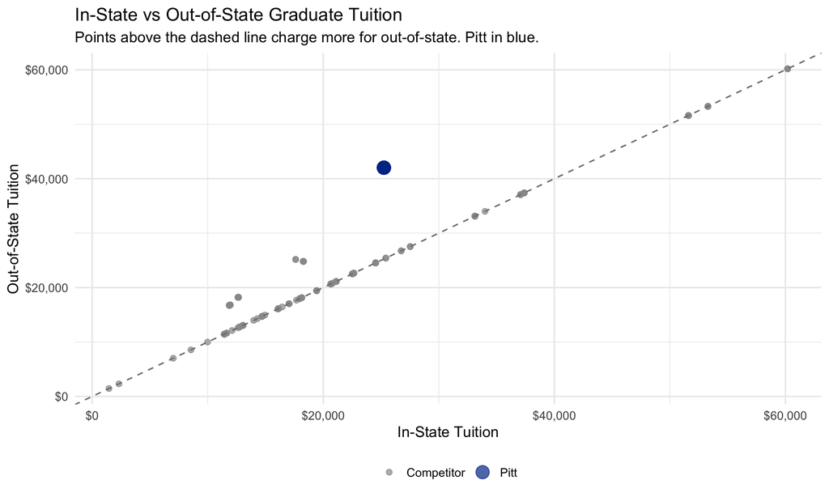

```r
tier1_tuition |>
  filter(!is.na(tuition_in_state), !is.na(tuition_out_of_state)) |>
  mutate(spread = tuition_out_of_state - tuition_in_state) |>
  ggplot(aes(x = tuition_in_state, y = tuition_out_of_state,
             color = is_pitt, size = is_pitt)) +
  geom_point(alpha = 0.7) +
  geom_abline(slope = 1, intercept = 0, linetype = "dashed", color = "gray50") +
  scale_x_continuous(labels = dollar) +
  scale_y_continuous(labels = dollar) +
  scale_color_manual(values = c("FALSE" = "#999999", "TRUE" = "#003594"),
                     labels = c("Competitor", "Pitt")) +
  scale_size_manual(values = c("FALSE" = 2, "TRUE" = 5),
                    labels = c("Competitor", "Pitt")) +
  labs(
    title = "In-State vs Out-of-State Graduate Tuition",
    subtitle = "Points above the dashed line charge more for out-of-state. Pitt in blue.",
    x = "In-State Tuition", y = "Out-of-State Tuition",
    color = NULL, size = NULL
  ) +
  theme_minimal(base_size = 13) +
  theme(legend.position = "bottom")
```

```r
tier1_tuition |>
  filter(!is.na(tuition_in_state), !is.na(tuition_out_of_state)) |>
  mutate(
    spread     = tuition_out_of_state - tuition_in_state,
    spread_pct = round(spread / tuition_in_state * 100, 0)
  ) |>
  group_by(shrs_program) |>
  summarise(
    pitt_spread     = dollar(max(spread[is_pitt], na.rm = TRUE)),
    pitt_spread_pct = paste0(max(spread_pct[is_pitt], na.rm = TRUE), "%"),
    avg_spread      = dollar(round(mean(spread[!is_pitt], na.rm = TRUE))),
    avg_spread_pct  = paste0(round(mean(spread_pct[!is_pitt], na.rm = TRUE)), "%"),
    .groups = "drop"
  ) |>
  select(
    Program           = shrs_program,
    `Pitt Spread`     = pitt_spread,
    `Pitt Spread %`   = pitt_spread_pct,
    `Avg Comp Spread`  = avg_spread,
    `Avg Comp Spread %` = avg_spread_pct
  ) |>
  kable() |>
  kable_styling(bootstrap_options = c("striped", "hover"), full_width = FALSE)
```

| Program | Pitt Spread | Pitt Spread % | Avg Comp Spread | Avg Comp Spread % |
| --- | --- | --- | --- | --- |
| AT | -Inf | -Inf% | $1,212 | 9% |
| AuD | $16,776 | 66% | $2,830 | 20% |
| DN | -Inf | -Inf% | $694 | 6% |
| DPT | $16,776 | 66% | $636 | 4% |
| HIM | $16,776 | 66% | $2,623 | 17% |
| OTD | $16,776 | 66% | $711 | 5% |
| PAS | $16,776 | 66% | $1,092 | 7% |
| SLP | $16,776 | 66% | $1,680 | 12% |
| SS | $16,776 | 66% | $880 | 7% |

# 6 - Key Findings

```r
# Programs where Pitt is more expensive than average
expensive <- tuition_comparison |>
  filter(!is.na(pitt_vs_avg_in), pitt_vs_avg_in > 0) |>
  arrange(desc(pitt_vs_avg_in))

if (nrow(expensive) > 0) {
  cat("## Pitt is above average in-state tuition for:\n\n")
  for (i in seq_len(nrow(expensive))) {
    cat(paste0("- **", expensive$shrs_program[i], "**: ",
               dollar(expensive$pitt_in_state[i]),
               " vs ", dollar(expensive$avg_in_state[i]),
               " avg (+", dollar(expensive$pitt_vs_avg_in[i]), ")\n"))
  }
  cat("\n")
}
```

## Pitt is above average in-state tuition for:

- **HIM**: $25,248 vs $17,982 avg (+$7,266)
- **SS**: $25,248 vs $19,575 avg (+$5,673)
- **OTD**: $25,248 vs $21,325 avg (+$3,923)
- **DPT**: $25,248 vs $23,224 avg (+$2,024)
- **SLP**: $25,248 vs $23,422 avg (+$1,826)
- **PAS**: $25,248 vs $24,399 avg (+$849)
- **AuD**: $25,248 vs $24,591 avg (+$657)

```r
# Programs where Pitt is cheaper
cheaper <- tuition_comparison |>
  filter(!is.na(pitt_vs_avg_in), pitt_vs_avg_in < 0) |>
  arrange(pitt_vs_avg_in)

if (nrow(cheaper) > 0) {
  cat("## Pitt is below average in-state tuition for:\n\n")
  for (i in seq_len(nrow(cheaper))) {
    cat(paste0("- **", cheaper$shrs_program[i], "**: ",
               dollar(cheaper$pitt_in_state[i]),
               " vs ", dollar(cheaper$avg_in_state[i]),
               " avg (", dollar(cheaper$pitt_vs_avg_in[i]), ")\n"))
  }
  cat("\n")
}

# Programs with no Pitt tuition data
missing <- tuition_comparison |> filter(is.na(pitt_in_state))
if (nrow(missing) > 0) {
  cat("## No Pitt tuition comparison available for: ",
      paste(missing$shrs_program, collapse = ", "),
      "\n\n(Pitt shows 0 IPEDS completions in these CIP codes.)\n\n")
}
```

## No Pitt tuition comparison available for: AT, DN

(Pitt shows 0 IPEDS completions in these CIP codes.)

```r
cat("## Context\n\n")
```

## Context

```r
cat(paste0("- IPEDS tuition is **institution-level**, not program-specific. ",
           "Actual program costs may differ due to differential tuition, fees, or clinical charges.\n"))
```

- IPEDS tuition is **institution-level**, not program-specific. Actual program costs may differ due to differential tuition, fees, or clinical charges.

```r
cat(paste0("- Data is from **academic year 2021** (most recent available in IPEDS).\n"))
```

- Data is from **academic year 2021** (most recent available in IPEDS).

```r
cat(paste0("- Pitt graduate in-state: **", dollar(pitt_in), "** | ",
           "Out-of-state: **", dollar(pitt_out), "**\n"))
```

- Pitt graduate in-state: **$25,248** | Out-of-state: **$42,024**

# Appendix

**Data Source**: IPEDS Academic Year Tuition via Urban Institute Education Data Portal API.

**Tuition Type Codes**: 2 = in-district, 3 = in-state, 4 = out-of-state. We use type 3 (in-state) and type 4 (out-of-state) for graduate level (level_of_study = 2).

**Important caveat**: IPEDS reports institution-level tuition, not program-specific. Many health professions programs charge differential tuition above the base rate. The numbers here represent the institutional baseline. Actual program costs for clinical doctorates (DPT, OTD, AuD) and professional programs (PAS) are typically higher than the institutional rate shown.